# FP1_ANTON_KOROLEV

```r
library(dplyr)
library(tidytuesdayR)
library(tidyverse)
```

```r
library(ggplot2)
```

STUDENT NAME - ANTON KOROLEV PROJECT AREA- COST OF EDUCATION & STUDENT DEBT OTHER MEMBERS - NOLAN MEYER

POTENTIAL RESEARCH QUESTIONS:

1. Who benefits the most from the loan forgiveness (gender, race, class)?
2. How has the cost of tuition tracked in comparison to inflation rates, cost of living, and post-college income?
3. What majors provide most financial security and “easiest” opportunities to pay off debt? Which majors require students to take out most money relative to cost of attendance?

DATASETS 1:

```r
data1 <- readr::read_csv("data1.csv")
data2 <- readr::read_csv("data2.csv")
```

Data source (who created it?) > This data comes from the National Center for Educational Studies website and , more specifically, from the National Postsecondary Student Aid Study: 2016 Undergraduates (NPSAS:UG).

Data description - what’s being measured? > The datalab of NCES website allows you to pick variables to create custom datasets. In this dataset I chose to investigate certain parameters of various fields of undergraduate studies. The variables include parents’ income of dependent children, cumulative amount borrowed, and adjusted gross income.

Data limitations (eg: are the data recent? do they contain all variables you might want?) > The data is relatively recent - the study was performed in 2016. We also have an access to previous studies that occured every 4 years, so we may also see changes over time in trends of this data. There is an abundance of variables relating to the questions we might want to ask.

Show the variable names. Describe the most useful / interesting ones. Visualize one interesting variable.

```r
colnames(data1)
```

```
## [1] "Field of study: undergraduate (23 categories)"
## [2] "Adjusted Gross Income (AGI)"
## [3] "Cumulative amount borrowed for undergrad"
## [4] "Dependent students: Parents' income"
```

```r
colnames(data1) <- c('study_field','agi','borrowed','parents_income')
```

> I am assuming a large portion of undergraduate students are dependent on their parents for money, so it should be very interesting to see if students of wealthier parents show any trends in field of study preferences.

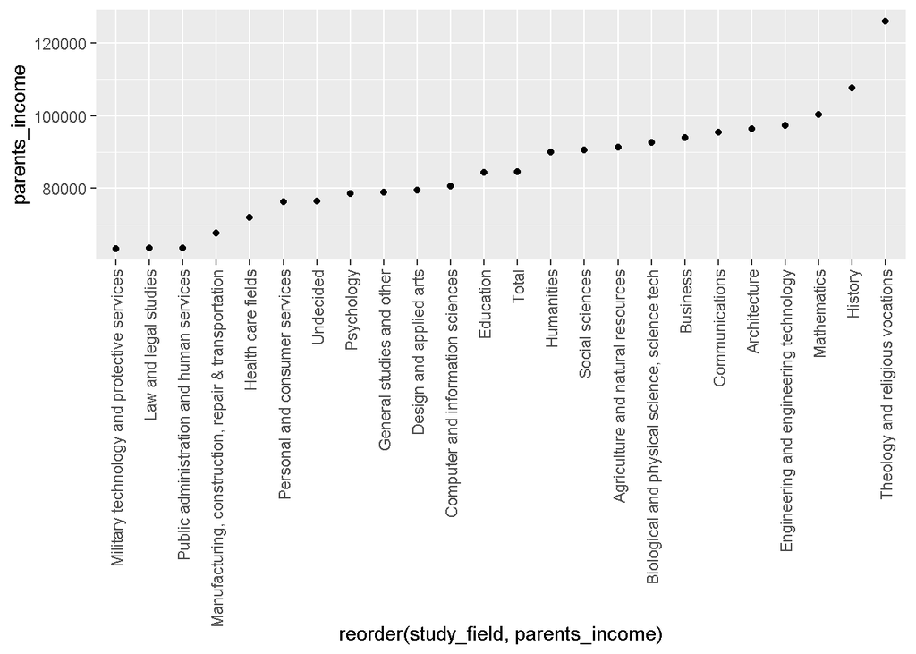

```r
ggplot(data1, aes(y=parents_income, x=reorder(study_field,parents_income))) +
  geom_point() +
  theme(axis.text.x = element_text(angle = 90, vjust = 0.5, hjust=1))
```

DATASETS 2:

Data source (who created it?) > This data was collected by the Bureau of Labor Statistics and released by FRED.

Data description - what’s being measured? > This data includes time series data for various CPI components, including total CPI, energy, shelter, food, and education.

Data limitations (eg: are the data recent? do they contain all variables you might want?) > The data is very reliable and is reported monthly. FRED has a vast library of variables I might be interested in this project.

Show the variable names. Describe the most useful / interesting ones. Visualize one interesting variable.

```r
colnames(data2)
```

```
## [1] "DATE"         "CUSR0000SEEB" "CPIAUCSL"     "CPIUFDSL"     "CPIENGSL"
## [6] "CUSR0000SAH1"
```

```r
colnames(data2) <- c('date','tuition','total','food','energy','shelter')
```

> When visualised it is very interesting to see how much faster the CPI for tuition has been growing much faster than total and other components.

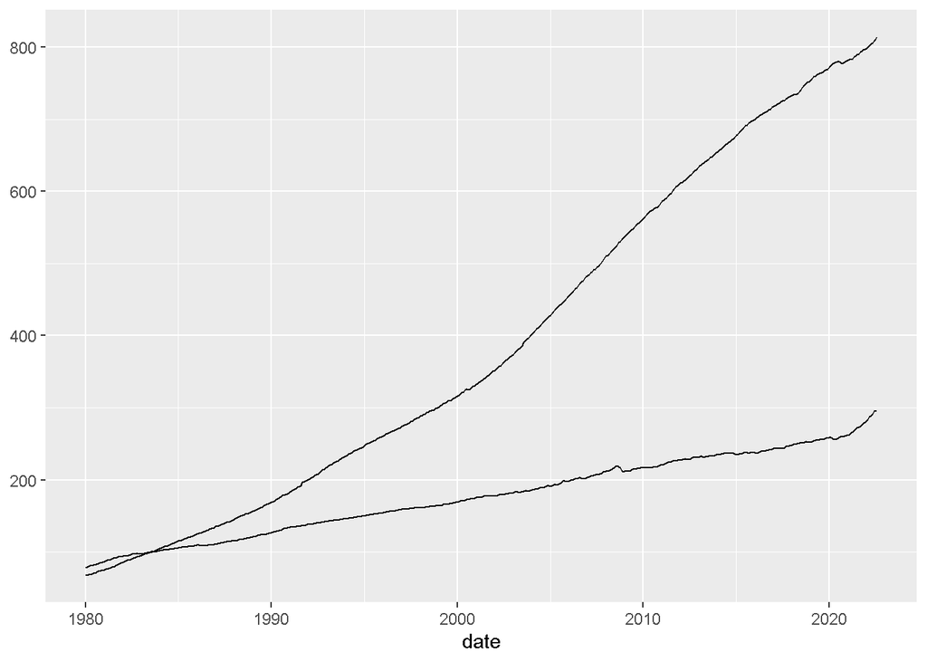

```r
ggplot(data2, aes(x=date)) +
  geom_line(aes(y=tuition)) +
  geom_line(aes(y=total)) +
  theme(axis.title.y=element_blank())
```